# Non-parametric test for difference in mean

Christoph Hafemeister

2021-02-11

> *NOTE:* This document was generated with `sctransform` version 0.3.2.9003

## Introduction

With this vignette we introduce the non-parametric differential expression test for sparse non-negative data as seen in single-cell RNA sequencing.

The test is a model-free randomization test where the observed difference in mean between two groups is compared against a null distribution that is obtained by random shuffling of the group labels.

Given the observed difference and the null distribution, empirical p-values are calculated: `emp_pval = (b + 1) / (R + 1)` where `b` is the number of times the absolute difference in mean from a random permutation is at least as large as the absolute value of the observed difference in mean, `R` is the number of random permutations. This is an upper bound of the real empirical p-value that would be obtained by enumerating all possible group label permutations.

Additionally, we approximate the empirical null distribution with a normal distribution and turn the observed difference in mean into a z-score and then into a p-value. Finally, all p-values (for the tested genes) are adjusted using the Benjamini & Hochberg method (fdr).

The log2FC values in the output are `log2(mean1 / mean2)`.

The current implementation only supports sparse matrices of class `dgCMatrix` from the `Matrix` package and has been optimized for speed (see benchmarking results below).

## Load some data

We use the publicly available “10k PBMCs from a Healthy Donor (v3 chemistry)” data (11,769 cells) from 10x Genomics available at https://support.10xgenomics.com/single-cell-gene-expression/datasets/3.0.0/pbmc_10k_v3

We apply the following filters:

- max nCount_RNA = 25,000
- min nFeature_RNA = 300
- max nFeature_RNA = 5,000
- max percent.mt = 20

10,939 cells remain and are mapped to cell types using [Azimuth](https://satijalab.org/azimuth/)

We then keep only those cell types that have at least 5 cells with mapping score > 0.66 and further remove all genes that have not been detected in at least 5 cells.

```r
counts <- Seurat::Read10X_h5("~/Projects/data_warehouse/raw_public_10x/pbmc_10k_v3_filtered_feature_bc_matrix.h5")
predictions <- read.delim("~/Projects/data_warehouse/raw_public_10x/pbmc_10k_v3_azimuth_pred.tsv",
    row.names = 1)

tab <- table(predictions$predicted.id, predictions$predicted.score > 0.66)
keep_types <- rownames(tab)[tab[, 2] >= 5]
keep_cells <- rownames(predictions)[predictions$predicted.id %in% keep_types]

counts <- counts[, keep_cells]
counts <- counts[rowSums(counts > 0) >= 5, ]
predictions <- predictions[keep_cells, ]

cell_types <- factor(predictions$predicted.id, levels = names(sort(table(predictions$predicted.id),
    decreasing = TRUE)))
```

We now have a count matrix of 18980 genes and 10919 cells with the following cell type labels:

```r
data.frame(table(cell_types))
```

| cell_types | Freq |
| --- | --- |
| CD14 Mono | 3319 |
| CD4 TCM | 1846 |
| B naive | 1021 |
| CD4 Naive | 826 |
| MAIT | 572 |
| NK | 562 |
| CD16 Mono | 402 |
| CD8 TEM | 372 |
| CD8 Naive | 354 |
| B memory | 269 |
| B intermediate | 245 |
| gdT | 225 |
| CD8 TCM | 160 |
| CD4 TEM | 152 |
| cDC2 | 150 |
| Platelet | 145 |
| Treg | 99 |
| pDC | 82 |
| NK Proliferating | 29 |
| NK_CD56bright | 27 |
| HSPC | 26 |
| ILC | 16 |
| cDC1 | 10 |
| Plasmablast | 10 |

## Motivation

Here we illustrate the concept of the test using CD14 Monocytes as group 1 and all remaining cells as group 2. We will show two example genes: MYL12A (not differentially expressed), and CD14.

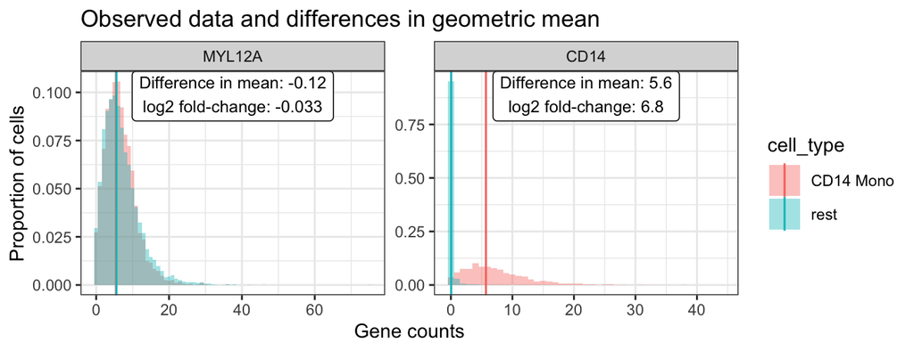

```r
goi <- c("MYL12A", "CD14")
df <- melt(t(as.matrix(counts[goi, , drop = FALSE])), varnames = c("cell", "gene"),
    value.name = "counts")
df$cell_type <- factor(c("rest", "CD14 Mono")[(cell_types == "CD14 Mono") + 1])
# calculate the (geometric) mean per group
df_sum <- group_by(df, gene, cell_type) %>% summarise(mean = expm1(mean(log1p(counts))),
    mid = median(range(counts)), .groups = "drop")
# and the difference of means
df_diff <- group_by(df_sum, gene) %>% summarise(diff_mean = mean[1] - mean[2], label = sprintf("Difference in mean: %1.2g\nlog2 fold-change: %1.2g",
    diff_mean, log2(mean[1]/mean[2])), x = max(mid), y = Inf, .groups = "drop")
p1 <- ggplot(df, aes(counts, y = ..density.., fill = cell_type)) + geom_histogram(binwidth = 1,
    position = "identity", alpha = 0.4) + geom_vline(data = df_sum, aes(xintercept = mean,
    color = cell_type)) + geom_label(data = df_diff, aes(x, y, label = label), vjust = 1,
    inherit.aes = FALSE, size = 3) + facet_wrap(~gene, scales = "free") + xlab("Gene counts") +
    ylab("Proportion of cells") + ggtitle("Observed data and differences in geometric mean")
plot(p1)
```

The plot above shows the UMI counts per gene per group. Also shown is the difference in mean (mean1 - mean2) and the log2 fold-change (log2(mean1 / mean2)). To find out whether the observed difference in mean is significant we look at the null distribution of difference in mean, i.e. we shuffle the labels (here we use 99 repetitions) and calculate the difference in mean.

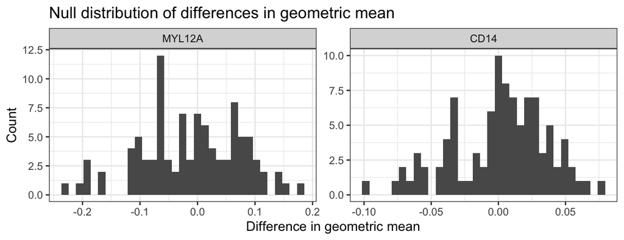

```r
# calculate null distribution of difference in mean for each gene
grp <- factor(c("rest", "CD14 Mono")[(cell_types == "CD14 Mono") + 1])
tmp_counts <- counts[goi, , drop = FALSE]
R <- 99
diff_mean_null <- sapply(1:R, function(i) {
    mean_r <- sctransform:::row_gmean_grouped_dgcmatrix(matrix = tmp_counts, group = grp,
        eps = 1, shuffle = TRUE)
    mean_r[, 1] - mean_r[, 2]
})
df_null <- melt(diff_mean_null, varnames = c("gene", "iteration"), value.name = "diff_mean")

p2 <- ggplot(df_null, aes(diff_mean)) + geom_histogram(bins = 33) + facet_wrap(~gene,
    scales = "free") + xlab("Difference in geometric mean") + ylab("Count") + ggtitle("Null distribution of differences in geometric mean")
plot(p2)
```

The null distribution of ‘difference in mean’ shown above indicates what values to expect if the null is true (no difference in mean between the two groups). We can use the distribution to obtain an empirical p-value by asking how often the absolute value of the null distribution is larger or equal to the observed difference in mean. We use the absolute value since this is a two-tailed test, and use a pseudo-count in nominator and denominator when turning the observed frequencies into p-values (see Phipson and Smyth (2010) and Hartwig (2013) for discussions).

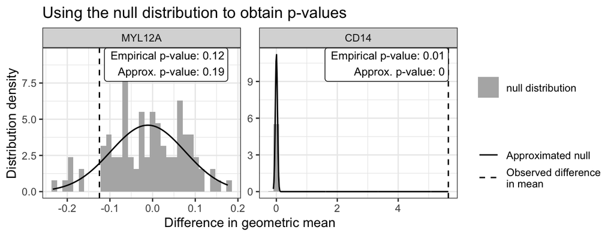

```r
# given the null distribution, get empirical p-value, fit a gaussian and get
# approximated p-value
df_res <- left_join(df_null, df_diff, by = "gene") %>% group_by(gene) %>% summarise(emp_pval = (sum((abs(diff_mean.x) -
    abs(diff_mean.y)) >= 0) + 1)/(R + 1), sds = sqrt(sum(diff_mean.x^2)/(R - 1)),
    zscore = (diff_mean.y[1] - mean(diff_mean.x))/sds, pval = 2 * pnorm(-abs(zscore)),
    min_r = min(diff_mean.x), max_r = max(diff_mean.x), mean_r = mean(diff_mean.x),
    observed = diff_mean.y[1], .groups = "drop")
df_fit <- group_by(df_res, gene) %>% summarise(x = seq(from = min(min_r, observed),
    to = max(max_r, observed), length.out = 333), y = dnorm(x = x, mean = mean_r,
    sd = sds), .groups = "drop")
df_anno <- group_by(df_res, gene) %>% summarise(x = max(max_r, observed), y = Inf,
    label = sprintf("Empirical p-value: %1.2g\nApprox. p-value: %1.2g", emp_pval,
        pval))

p3 <- ggplot(df_null, aes(diff_mean, y = ..density..)) + geom_histogram(bins = 33,
    aes(fill = "gray70")) + geom_line(data = df_fit, aes(x = x, y = y, linetype = "1")) +
    geom_vline(data = df_res, aes(xintercept = observed, linetype = "2"), show_guide = FALSE) +
    geom_label(data = df_anno, aes(x, y, label = label), hjust = 1, vjust = 1, size = 3) +
    facet_wrap(~gene, scales = "free") + xlab("Difference in geometric mean") + ylab("Distribution density") +
    ggtitle("Using the null distribution to obtain p-values") + scale_fill_manual(name = "",
    values = "gray70", labels = sprintf("null distribution", R)) + scale_linetype_manual(name = "",
    values = c(1, 2), labels = c("Approximated null", "Observed difference\nin mean"))
plot(p3)
```

The lowest possible empirical p-value is 1/(R+1) whith R being the number of random permutation used. However, the gaussian approximation of the null distribution allows us to calculate z-scores and consequently p-values that are lower than that. While the approximation using a gaussian might not be exact, especially for genes with very low detection rate or when cell numbers are very low, it generally agrees well with the empirical data.

## Example 1: DE of CD14 Mono vs CD16 Mono (one vs one)

First, we will take the count matrix and fit a model using `sctransform::vst`, and in a second step obtain corrected counts (with the sequencing depth effect removed). Then compare the two groups.

```r
vst_out <- vst(umi = counts, method = "qpoisson", residual_type = "none", return_cell_attr = TRUE,
    verbosity = 0)
counts_corrected <- correct_counts(x = vst_out, umi = counts, verbosity = 0)
```

By default `sctransform::diff_mean_test` applies some moderate pre-filtering and tests only genes with:

- absolute log2-fold-change of at least log2(1.2) (0.2630344) AND
- mean value of at least 0.05 in at least one of the tested groups AND
- at least 5 non-zero observations in the group with higher mean

Here we disable the first filter, but require a mean of at least 0.1 in at least one of the groups. We show results as a volcano plot and highlight the top DE genes (based on p-value or log-fold-change).

```r
bm <- bench::mark(de_res <- diff_mean_test(y = counts_corrected, group_labels = cell_types,
    compare = c("CD14 Mono", "CD16 Mono"), log2FC_th = 0, mean_th = 0.1), max_iterations = 1,
    filter_gc = FALSE)
```

```
#> Non-parametric DE test for count data
#> Using geometric mean and 99 random permutations
#> Input: 18980 genes, 10919 cells; 24 groups
#> Comparing CD14 Mono (group1, N = 3319) to CD16 Mono (group2, N = 402)
#> Keeping 6727 genes after initial filtering
#> Non-parametric DE test for count data
#> Using geometric mean and 99 random permutations
#> Input: 18980 genes, 10919 cells; 24 groups
#> Comparing CD14 Mono (group1, N = 3319) to CD16 Mono (group2, N = 402)
#> Keeping 6727 genes after initial filtering
```

```r
knitr::kable(data.frame(bm[, 5:9]), caption = "Benchmarking details")
```

Benchmarking details

| mem_alloc | gc.sec | n_itr | n_gc | total_time |
| --- | --- | --- | --- | --- |
| 352MB | 0.4363543 | 1 | 1 | 2.29s |

The runtime for the tests was 2.29s. In total, 6727 genes were tested. 897 genes showed a mean that was significantly different between groups (FDR <= 0.05 based on empirical p-values) AND had an absolute log2 fold-change of at least 1 (i.e. `abs(log2(mean1/mean2)) >= 1`).

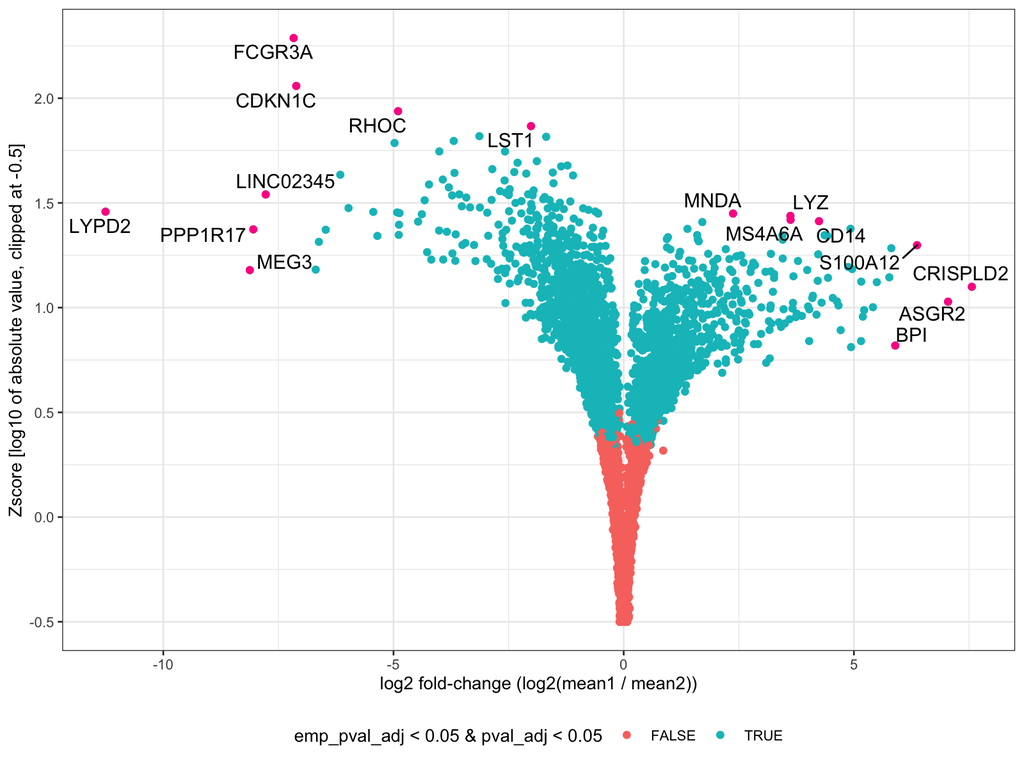

```r
top_markers <- arrange(de_res, sign(log2FC), -abs(log2FC)) %>% group_by(sign(log2FC)) %>%
    filter(rank(-abs(zscore), ties.method = "first") <= 4 | rank(-abs(log2FC), ties.method = "first") <=
        4) %>% ungroup() %>% select(gene, mean1, mean2, log2FC, emp_pval_adj, pval_adj,
    zscore)

p1 <- ggplot(de_res, aes(log2FC, pmax(-0.5, log10(abs(zscore))))) + geom_point(aes(color = emp_pval_adj <
    0.05 & pval_adj < 0.05)) + geom_point(data = top_markers, color = "deeppink") +
    geom_text_repel(data = top_markers, mapping = aes(label = gene)) + theme(legend.position = "bottom") +
    ylab("Zscore [log10 of absolute value, clipped at -0.5]") + xlab("log2 fold-change (log2(mean1 / mean2))")

show(p1)
```

Top markers per cell type

```r
filter(top_markers, log2FC < 0) %>% DT::datatable(rownames = FALSE, options = list(paging = FALSE,
    searching = FALSE)) %>% DT::formatRound(2:7, digits = 2)
```

| gene | mean1 | mean2 | log2FC | emp_pval_adj | pval_adj | zscore |
| --- | --- | --- | --- | --- | --- | --- |
| LYPD2 | 0.00020886398456806 | 0.510172710276141 | -11.2542062713192 | 0.0201046025104602 | 2.20071180425566e-179 | -28.7208749195605 |
| MEG3 | 0.000626722835307844 | 0.174519634298763 | -8.1213460801633 | 0.0201046025104602 | 3.10658788963066e-50 | -15.1076987591926 |
| PPP1R17 | 0.000417771593300169 | 0.11029614115307 | -8.04445220341935 | 0.0201046025104602 | 8.33263617427858e-122 | -23.6459029809672 |
| LINC02345 | 0.00146296431839116 | 0.320576636136938 | -7.77563089175059 | 0.0201046025104602 | 1.01534212174538e-261 | -34.7123405397689 |
| FCGR3A | 0.0868559537550815 | 12.4927903001621 | -7.16825528222292 | 0.0201046025104602 | 0 | -193.792550903715 |
| CDKN1C | 0.031742257789058 | 4.38936777885667 | -7.1114645973878 | 0.0201046025104602 | 0 | -114.4115741895 |
| RHOC | 0.11176955015525 | 3.33947721438102 | -4.90102316319274 | 0.0201046025104602 | 0 | -86.6815601640678 |
| LST1 | 5.02588158510689 | 20.2927890849156 | -2.01351858048982 | 0.0201046025104602 | 0 | -73.5899181228086 |

```r
filter(top_markers, log2FC > 0) %>% DT::datatable(rownames = FALSE, options = list(paging = FALSE,
    searching = FALSE)) %>% DT::formatRound(2:7, digits = 2)
```

| gene | mean1 | mean2 | log2FC | emp_pval_adj | pval_adj | zscore |
| --- | --- | --- | --- | --- | --- | --- |
| CRISPLD2 | 0.325856353973763 | 0.0017257340859231 | 7.56088213621159 | 0.0201046025104602 | 4.30548499983607e-35 | 12.5783493730858 |
| ASGR2 | 0.227881165173309 | 0.0017257340859231 | 7.04492769737336 | 0.0201046025104602 | 1.48612627497546e-25 | 10.677844221147 |
| S100A12 | 12.7671688743381 | 0.154222200939983 | 6.37128436970858 | 0.0201046025104602 | 3.18126640970606e-86 | 19.8685717135231 |
| BPI | 0.10287492502424 | 0.0017257340859231 | 5.8975373886304 | 0.0201046025104602 | 2.27568492497294e-10 | 6.59185459684849 |
| CD14 | 4.19656086570376 | 0.221715567170799 | 4.24242553151072 | 0.0201046025104602 | 1.15551457930684e-145 | 25.8692672573388 |
| MS4A6A | 4.57517605411814 | 0.371090518221813 | 3.6239842156481 | 0.0201046025104602 | 3.46078838725488e-150 | 26.2695894250503 |
| LYZ | 96.6628759280804 | 7.85952387219418 | 3.62044809650608 | 0.0201046025104602 | 1.47872050634385e-163 | 27.4180606554652 |
| MNDA | 9.41488850744475 | 1.81490550060929 | 2.3750495791016 | 0.0201046025104602 | 3.51008674334651e-172 | 28.1345393144912 |

## Example 2: Top markers for all cell types (each vs rest)

Here we use the test to find genes that are high for each cell type compared to the rest. This is the default behavior of the test function. To speed things up, we use fewer random permutations (49) and test only the 222 genes with highest log2 fold-change.

```r
bm <- bench::mark(de_res <- diff_mean_test(y = counts_corrected, group_labels = cell_types,
    R = 49, only_pos = TRUE, only_top_n = 222, verbosity = 0))
knitr::kable(data.frame(bm[, 5:9]), caption = "Benchmarking details")
```

Benchmarking details

| mem_alloc | gc.sec | n_itr | n_gc | total_time |
| --- | --- | --- | --- | --- |
| 906MB | 0.2190636 | 1 | 1 | 4.57s |

Show one plot per cell type and highlight the top 4 markers with respect to p-value and the top 4 markers with respect to log2FC.

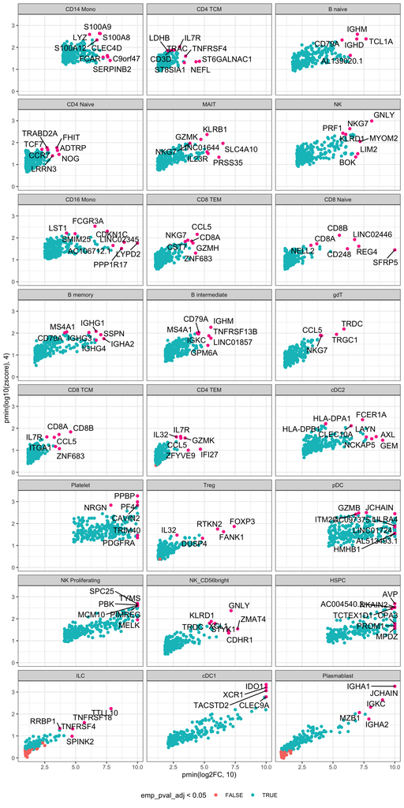

```r
top_markers <- group_by(de_res, group1) %>% filter(rank(-zscore, ties.method = "first") <=
    4 | rank(-log2FC, ties.method = "first") <= 4) %>% select(group1, gene, mean1,
    mean2, log2FC, zscore, emp_pval_adj)

p1 <- ggplot(de_res, aes(pmin(log2FC, 10), pmin(log10(zscore), 4))) + geom_point(aes(color = emp_pval_adj <
    0.05)) + geom_point(data = top_markers, color = "deeppink") + geom_text_repel(data = top_markers,
    mapping = aes(label = gene)) + facet_wrap(~group1, ncol = 3) + theme(legend.position = "bottom")
show(p1)
```

Table of top markers per cell type

```r
DT::datatable(top_markers, rownames = FALSE) %>% DT::formatRound(3:7, digits = 2)
```

| group1 | gene | mean1 | mean2 | log2FC | zscore | emp_pval_adj |
| --- | --- | --- | --- | --- | --- | --- |
| CD14 Mono | S100A9 | 136.674151025734 | 1.12495490954946 | 6.9247294273109 | 436.701186233358 | 0.02 |
| CD14 Mono | S100A12 | 12.7671688743381 | 0.120766647306116 | 6.72407275819563 | 220.289028465302 | 0.02 |
| CD14 Mono | S100A8 | 86.6485707776914 | 0.683868915235823 | 6.98531232866501 | 427.211743814197 | 0.02 |
| CD14 Mono | C9orf47 | 0.105864155199973 | 0.0005473712113138 | 7.59547891212345 | 36.6252500962503 | 0.02 |
| CD14 Mono | CLEC4D | 0.258309295195146 | 0.00136898985811181 | 7.55984399046656 | 42.4414901315995 | 0.02 |
| CD14 Mono | LYZ | 96.6628759280804 | 1.38640763989399 | 6.12353850386409 | 391.213167392432 | 0.02 |
| CD14 Mono | SERPINB2 | 0.0604216013982176 | 0.00027364816399807 | 7.78659843412825 | 25.5110043359454 | 0.02 |
| CD14 Mono | FCAR | 0.135937368644314 | 0.000912451794980773 | 7.21897804342916 | 35.8122061438735 | 0.02 |
| CD4 TCM | TNFRSF4 | 0.22120676647832 | 0.0198179231601501 | 3.48051782991277 | 39.7088585737383 | 0.02 |
| CD4 TCM | IL7R | 5.98152154262937 | 0.74716422459527 | 3.00101523169676 | 106.912522509098 | 0.02 |

[output cut: 144 more lines]

## Example 3: Unique markers for all cell types (all vs all)

Since the test is pretty fast we can run all pairwise comparisons to try to find genes that are cell type specific across many individual comparisons.

```r
bm <- bench::mark(de_res <- diff_mean_test(y = counts_corrected, group_labels = cell_types,
    compare = "all_vs_all", R = 49, mean_th = 0.1, log2FC_th = 0, verbosity = 0))
knitr::kable(data.frame(bm[, 5:9]), caption = "Benchmarking details")
```

Benchmarking details

| mem_alloc | gc.sec | n_itr | n_gc | total_time |
| --- | --- | --- | --- | --- |
| 63.3GB | 0.8631359 | 1 | 118 | 2.28m |

There are 276 unique cell type pairs in the output. On average 5420 genes were tested in each comparison. Below we list the top genes per cell type ranked by fold change and the number of times it was a cell type marker (absolute log2FC >= 0 and p-value <= 0.05). We also show the minimum log2 fold-change and the maximum p-value across all comparisons.

```r
log2fc_th <- 0  #log2(1.2)
p_th <- 0.05
fn <- function(fc, pval, fc_th = 0, p_th = Inf) {
    worst <- which.min(fc)
    wp <- pval[worst]
    if (fc[worst] < 0) {
        wp <- 1 - wp
    }
    data.frame(n = sum(fc >= fc_th & pval <= p_th), log2FC = fc[worst], pval = wp)
}
tmp1 <- group_by(de_res, gene, group1) %>% summarise(fn(log2FC, pval))

tmp1 <- group_by(de_res, gene, group1) %>% summarise(n = sum(log2FC >= log2fc_th),
    n_sig = sum(log2FC >= log2fc_th & pval <= p_th), log2FC = min(log2FC), pval = max(pval,
        log2FC < 0))

tmp2 <- group_by(de_res, gene, group2) %>% summarise(n = sum(log2FC <= -log2fc_th),
    n_sig = sum(log2FC <= -log2fc_th & pval <= p_th), log2FC = min(-log2FC), pval = max(pval,
        log2FC < 0))

top_markers <- full_join(tmp1, tmp2, by = c(group1 = "group2", gene = "gene")) %>%
    rename(cell_type = group1) %>% mutate(comparisons = mapply(sum, n.x, n.y, na.rm = TRUE),
    n_sig = mapply(sum, n_sig.x, n_sig.y, na.rm = TRUE), log2FC = pmin(log2FC.x,
        log2FC.y, na.rm = TRUE), pval = pmax(pval.x, pval.y, na.rm = TRUE)) %>% arrange(cell_type,
    -comparisons, -log2FC * n_sig, pval) %>% group_by(cell_type) %>% slice_head(n = 4) %>%
    select(cell_type, gene, comparisons, log2FC, pval)

DT::datatable(top_markers, rownames = FALSE, caption = "Cell type specific markers") %>%
    DT::formatRound(4:5, digits = 2)
```

| cell_type | gene | comparisons | log2FC | pval |
| --- | --- | --- | --- | --- |
| CD14 Mono | CLEC4D | 23 | 5.2220115448211 | 0.0434785622379587 |
| CD14 Mono | S1PR3 | 23 | 5.22944312374109 | 0.0754091030056088 |
| CD14 Mono | S100A8 | 23 | 4.50647734514398 | 0.000915620483745984 |
| CD14 Mono | S100A9 | 23 | 4.36177764232992 | 5.81805188114032e-05 |
| CD4 TCM | CD5 | 23 | 0.667744124970251 | 0.0618340531414427 |
| CD4 TCM | AP002884.1 | 23 | 0.342918577155658 | 0.69843316197964 |
| CD4 TCM | STAT5B | 23 | 0.21531514051301 | 0.591049654514597 |
| CD4 TCM | TRAT1 | 23 | 0.145982928203713 | 0.271669737897111 |
| B naive | AL139020.1 | 23 | 3.29277651358058 | 0.190200581610526 |
| B naive | IL4R | 23 | 2.39173137029782 | 0.0197553077379977 |

[output cut: 86 more lines]

Heatmap of top markers

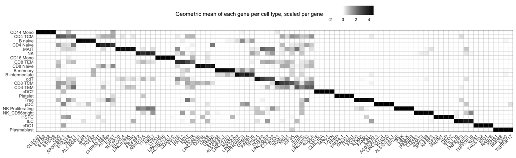

```r
mat <- sctransform:::row_gmean_grouped_dgcmatrix(matrix = counts_corrected[unique(top_markers$gene),
    ], group = cell_types, eps = 1, shuffle = FALSE)
mat <- t(scale(t(mat)))

p1 <- melt(mat, varnames = c("gene", "celltype")) %>% mutate(celltype = factor(celltype,
    levels = rev(colnames(mat)))) %>% ggplot(aes(gene, celltype, fill = value)) +
    geom_tile(colour = "gray66") + scale_fill_gradient2(low = "white", mid = "white",
    high = "black", name = "Geometric mean of each gene per cell type, scaled per gene") +
    theme(axis.text.x = element_text(angle = 45, vjust = 1, hjust = 1)) + labs(x = NULL,
    y = NULL) + scale_x_discrete(expand = c(0, 0)) + scale_y_discrete(expand = c(0,
    0)) + theme(legend.position = "top", axis.ticks = element_blank())
show(p1)
```

## Example 4: CD4 vs CD8 T cells (some vs some)

We can also test one or more groups against one or more other groups. As an example we test CD4 vs CD8 cells (in each group we combine Naive, TCM, TEM subgroups). The cell type identities for the comparison are passed as a list of length two to the `compare` argument of the `diff_mean_test` function.

```r
bm <- bench::mark(de_res <- diff_mean_test(y = counts_corrected, group_labels = cell_types,
    compare = list(c("CD4 Naive", "CD4 TCM", "CD4 TEM"), c("CD8 Naive", "CD8 TCM",
        "CD8 TEM")), log2FC_th = 0, mean_th = 0.1), max_iterations = 1, filter_gc = FALSE)
```

```
#> Non-parametric DE test for count data
#> Using geometric mean and 99 random permutations
#> Input: 18980 genes, 10919 cells; 24 groups
#> Comparing group1 (group1, N = 2824) to group2 (group2, N = 886)
#> Keeping 4572 genes after initial filtering
#> Non-parametric DE test for count data
#> Using geometric mean and 99 random permutations
#> Input: 18980 genes, 10919 cells; 24 groups
#> Comparing group1 (group1, N = 2824) to group2 (group2, N = 886)
#> Keeping 4572 genes after initial filtering
```

```r
knitr::kable(data.frame(bm[, 5:9]), caption = "Benchmarking details")
```

Benchmarking details

| mem_alloc | gc.sec | n_itr | n_gc | total_time |
| --- | --- | --- | --- | --- |
| 297MB | 0 | 1 | 0 | 1.9s |

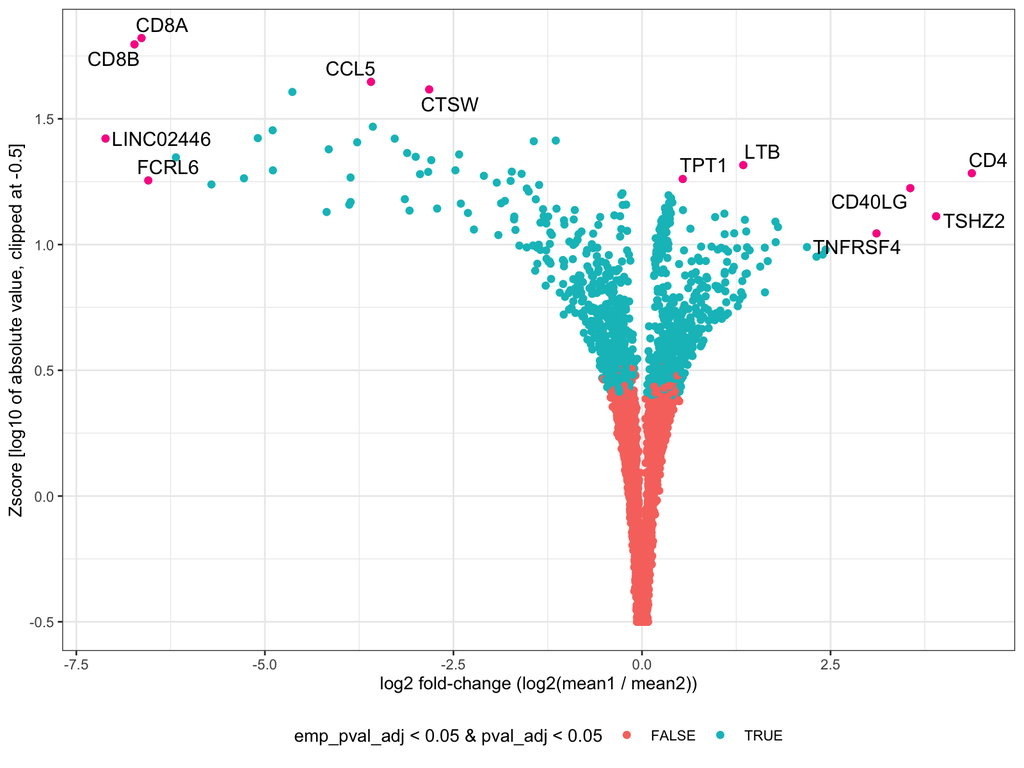

```r
top_markers <- arrange(de_res, sign(log2FC), -abs(log2FC)) %>% group_by(sign(log2FC)) %>%
    filter(rank(-abs(zscore), ties.method = "first") <= 4 | rank(-abs(log2FC), ties.method = "first") <=
        4) %>% ungroup() %>% select(gene, mean1, mean2, log2FC, emp_pval_adj, pval_adj,
    zscore)

p1 <- ggplot(de_res, aes(log2FC, pmax(-0.5, log10(abs(zscore))))) + geom_point(aes(color = emp_pval_adj <
    0.05 & pval_adj < 0.05)) + geom_point(data = top_markers, color = "deeppink") +
    geom_text_repel(data = top_markers, mapping = aes(label = gene)) + theme(legend.position = "bottom") +
    ylab("Zscore [log10 of absolute value, clipped at -0.5]") + xlab("log2 fold-change (log2(mean1 / mean2))")

show(p1)
```

Top markers per group

```r
filter(top_markers, log2FC < 0) %>% DT::datatable(rownames = FALSE, options = list(paging = FALSE,
    searching = FALSE), caption = "Higher in CD8") %>% DT::formatRound(2:7, digits = 2)
```

| gene | mean1 | mean2 | log2FC | emp_pval_adj | pval_adj | zscore |
| --- | --- | --- | --- | --- | --- | --- |
| LINC02446 | 0.00218857632554781 | 0.302909754426194 | -7.11275152877253 | 0.0430508474576271 | 7.03752366934308e-151 | -26.3995835122202 |
| CD8B | 0.0196251446589078 | 2.08219592773563 | -6.72925872932795 | 0.0430508474576271 | 0 | -62.5271603921378 |
| CD8A | 0.0190653616943067 | 1.89571998037579 | -6.63564816601852 | 0.0430508474576271 | 0 | -66.2582554355164 |
| FCRL6 | 0.00112600663937961 | 0.105212439673157 | -6.54594614575451 | 0.0430508474576271 | 3.3711136737933e-70 | -17.9893881795244 |
| CCL5 | 0.276915282913057 | 3.34159539297468 | -3.59302047644668 | 0.0430508474576271 | 0 | -44.3566298751074 |
| CTSW | 0.234017334534667 | 1.65424747815779 | -2.82148777554949 | 0.0430508474576271 | 0 | -41.3888653909032 |

```r
filter(top_markers, log2FC > 0) %>% DT::datatable(rownames = FALSE, options = list(paging = FALSE,
    searching = FALSE), caption = "Higher in CD4") %>% DT::formatRound(2:7, digits = 2)
```

| gene | mean1 | mean2 | log2FC | emp_pval_adj | pval_adj | zscore |
| --- | --- | --- | --- | --- | --- | --- |
| CD4 | 0.379036296546249 | 0.0182918846586946 | 4.37306037526353 | 0.0430508474576271 | 5.04289868643786e-80 | 19.2152787769523 |
| TSHZ2 | 0.297818085702685 | 0.0199477111206131 | 3.90013624711145 | 0.0430508474576271 | 1.26014884924724e-36 | 12.9548737752485 |
| CD40LG | 0.4761173191947 | 0.0404448997499809 | 3.55728741906714 | 0.0430508474576271 | 5.66592958938289e-61 | 16.762550009793 |
| TNFRSF4 | 0.155014464774286 | 0.0179613014016654 | 3.10943905244239 | 0.0430508474576271 | 6.24825711438345e-27 | 11.0730858234441 |
| LTB | 7.93207150820293 | 3.12802709215409 | 1.34244467560159 | 0.0430508474576271 | 7.07931989744795e-93 | 20.7053956622415 |
| TPT1 | 74.5242157632575 | 51.2443643524633 | 0.540315936872331 | 0.0430508474576271 | 4.80478667354416e-72 | 18.225183066535 |

## Example 5: Using the test with Seurat

The functionality outlined in the examples above can also be applied to Seurat objects. We demonstrate this with an example below where we perform unsupervised clustering followed by cluster marker identification (as in example 2).

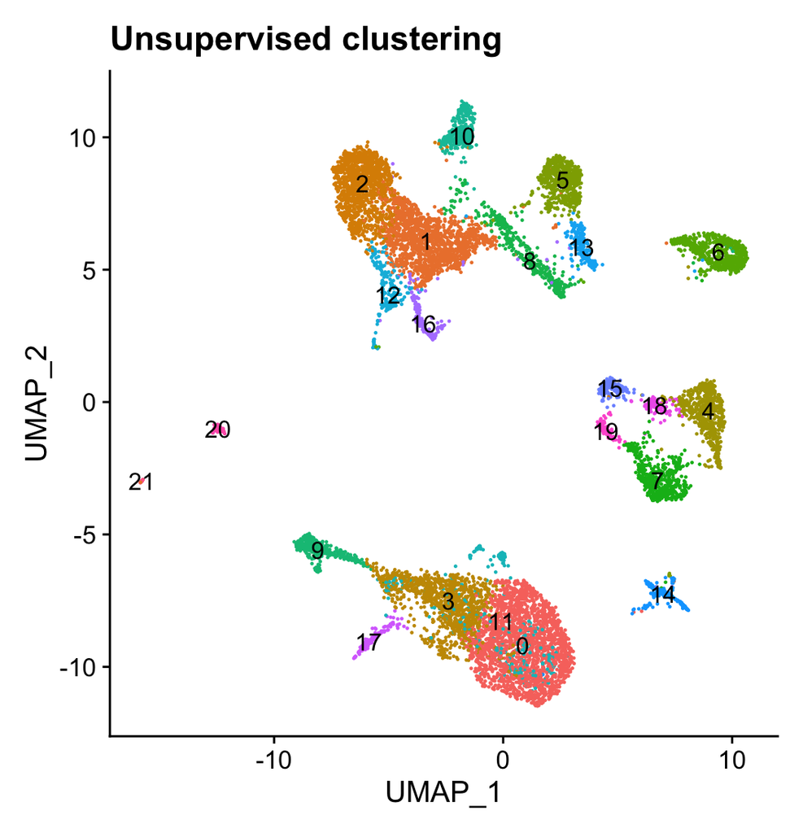

```r
library("Seurat")
s <- CreateSeuratObject(counts = counts)
# run sctransform
s <- SCTransform(s, verbose = FALSE, method = "qpoisson")
# 'standard' workflow
s <- RunPCA(s, verbose = FALSE)
s <- RunUMAP(s, dims = 1:30, verbose = FALSE)
s <- FindNeighbors(s, dims = 1:30, verbose = FALSE)
s <- FindClusters(s, verbose = FALSE)
DimPlot(s, label = TRUE) + NoLegend() + ggtitle("Unsupervised clustering")
```

The cells have been grouped into 22 clusters. We are now going to use `sctransform::diff_mean_test` to find the top cluster markers. For this we access the normalized counts that are in the `SCT` assay and the cluster labels.

```r
bm <- bench::mark(de_res <- diff_mean_test(y = GetAssayData(s, assay = "SCT", slot = "counts"),
    group_labels = s$seurat_clusters, R = 49, only_pos = TRUE, only_top_n = 222,
    verbosity = 0))
knitr::kable(data.frame(bm[, 5:9]), caption = "Benchmarking details")
```

Benchmarking details

| mem_alloc | gc.sec | n_itr | n_gc | total_time |
| --- | --- | --- | --- | --- |
| 817MB | 0 | 1 | 0 | 4.59s |

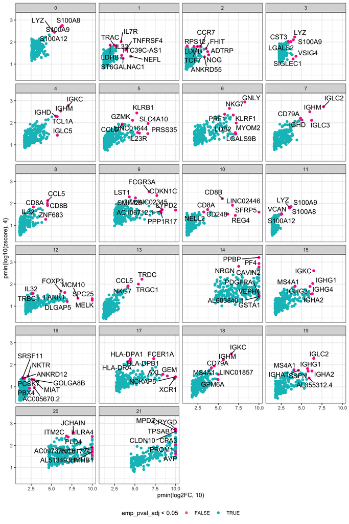

```r
top_markers <- group_by(de_res, group1) %>% filter(rank(-zscore, ties.method = "first") <=
    4 | rank(-log2FC, ties.method = "first") <= 4) %>% select(group1, gene, mean1,
    mean2, log2FC, zscore, emp_pval_adj)

p1 <- ggplot(de_res, aes(pmin(log2FC, 10), pmin(log10(zscore), 4))) + geom_point(aes(color = emp_pval_adj <
    0.05)) + geom_point(data = top_markers, color = "deeppink") + geom_text_repel(data = top_markers,
    mapping = aes(label = gene)) + facet_wrap(~group1, ncol = 4) + theme(legend.position = "bottom")
show(p1)
```

Table of top markers per cluster

```r
DT::datatable(top_markers, rownames = FALSE) %>% DT::formatRound(3:7, digits = 2)
```

| group1 | gene | mean1 | mean2 | log2FC | zscore | emp_pval_adj |
| --- | --- | --- | --- | --- | --- | --- |
| 0 | S100A9 | 192.092134323341 | 2.69300738778278 | 6.15643644773256 | 505.99520806429 | 0.02 |
| 0 | S100A12 | 19.9482957676927 | 0.484890120999163 | 5.36246382746427 | 278.43930096851 | 0.02 |
| 0 | S100A8 | 139.652052172303 | 1.74857551891791 | 6.31951285811973 | 564.536354687794 | 0.02 |
| 0 | LYZ | 107.547291699234 | 3.07374503974579 | 5.12882988276977 | 320.007609586864 | 0.02 |
| 1 | TNFRSF4 | 0.287708645390398 | 0.0195935649331105 | 3.87615675701927 | 43.6683930501835 | 0.02 |
| 1 | IL7R | 7.81951960278741 | 0.79148212029709 | 3.30445131221784 | 103.625902918159 | 0.02 |
| 1 | NEFL | 0.0785895175720976 | 0.00352123476864562 | 4.48018357250503 | 22.6895629054938 | 0.02 |
| 1 | LDHB | 5.31257658242141 | 1.36294528188979 | 1.96268408969414 | 72.4710494457521 | 0.02 |
| 1 | TRAC | 4.52034922156382 | 0.823876385128031 | 2.45593443699414 | 71.9036284106383 | 0.02 |
| 1 | IL32 | 6.56722994691621 | 1.02377030182853 | 2.68139290962616 | 65.67191271126 | 0.02 |

[output cut: 135 more lines]

Seurat heatmap

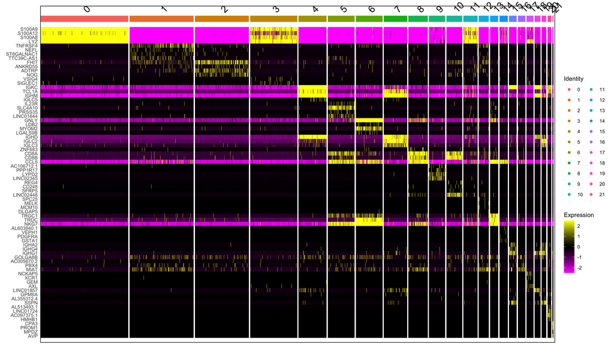

```r
marker_genes <- group_by(de_res, group1) %>% filter(rank(-log2FC, ties.method = "first") <=
    4) %>% pull(gene)
# make sure all markers are in the scale.data slot (by default only the highly
# variable genes are there)
s <- GetResidual(s, features = marker_genes, verbose = FALSE)
DoHeatmap(s, features = marker_genes, slot = "scale.data")
```

Runtime

```r
print(proc.time() - tic)
```

```
#>    user  system elapsed
#> 670.921  91.221 775.743
```

## References

Hartwig, Fernando Pires. 2013. “Two-Tailed P-Values Calculation in Permutation Based Tests: A Warning Against ‘Asymptotic Bias’ in Randomized Clinical Trials.” *Journal of Clinical Trials*, September. https://doi.org/10.4172/2167-0870.1000145.

Phipson, Belinda, and Gordon K Smyth. 2010. “Permutation P-Values Should Never Be Zero: Calculating Exact P-Values When Permutations Are Randomly Drawn.” *Statistical Applications in Genetics and Molecular Biology* 9 (1). https://doi.org/10.2202/1544-6115.1585.